# Project 1: Wrangling, Exploration, Visualization

SDS322E

## Data Wrangling, Exploration, Visualization

#### Cameron Dang crd2724

### Introduction

I downloaded the google.csv and Amazon.csv datasets from the sources https://www.kaggle.com/pavan9065/google-stock-history and https://www.kaggle.com/kannan1314/amazon-stock-price-all-time, respectively. They have the date ID variable in common, which is formatted YYYY-MM-DD, and each data set has six numeric variables in common including the opening, high, low, close, and adjusted close prices, and the volume of shares traded. I chose these data sets because they are formatted similarly, and I have an interest in this data because I am an Amazon shareholder. I expect that the price movements will be similar over a long period of time since they are both successful technology companies. Note that the values contained in the open, high, low, close, and adjusted close columns indicate the corresponding prices on that particular day in U.S. dollars. The values contained in the volume column indicate the number of shares of the stock traded on that particular day.

```r
library(tidyverse)
library(gt)
goog <- read_csv("~/Documents/Fall 2021/SDS322E/project1/google.csv")
amzn <- read_csv("~/Documents/Fall 2021/SDS322E/project1/Amazon.csv")
```

### Tidying: Reshaping

The amzn and goog datasets are already tidy, so I used the pivot_wider() function on goog to make it untidy. Each observation had its own row before this function was applied. After it was applied, each date had its own column. I made it tidy again by using the pivot_longer() function and selecting all of the date columns.

```r
# Datasets are tidy already. Untidying goog dataset
googUntidy = goog %>% pivot_wider(names_from="Date",values_from="Open")
googUntidy %>% head
```

```
## # A tibble: 6 × 4,316
##    High   Low Close `Adj Close`   Volume `2004-08-19` `2004-08-20` `2004-08-23`
##   <dbl> <dbl> <dbl>       <dbl>    <dbl>        <dbl>        <dbl>        <dbl>
## 1  51.8  47.8  50.0        50.0 44871361         49.8         NA           NA
## 2  54.3  50.1  54.0        54.0 22942874         NA           50.3         NA
## 3  56.5  54.3  54.5        54.5 18342897         NA           NA           55.2
## 4  55.6  51.6  52.2        52.2 15319808         NA           NA           NA
## 5  53.8  51.7  52.8        52.8  9232276         NA           NA           NA
## 6  53.8  52.1  53.8        53.8  7128620         NA           NA           NA
## # … with 4,308 more variables: 2004-08-24 <dbl>, 2004-08-25 <dbl>,
## #   2004-08-26 <dbl>, 2004-08-27 <dbl>, 2004-08-30 <dbl>, 2004-08-31 <dbl>,
## #   2004-09-01 <dbl>, 2004-09-02 <dbl>, 2004-09-03 <dbl>, 2004-09-07 <dbl>,
## #   2004-09-08 <dbl>, 2004-09-09 <dbl>, 2004-09-10 <dbl>, 2004-09-13 <dbl>,
## #   2004-09-14 <dbl>, 2004-09-15 <dbl>, 2004-09-16 <dbl>, 2004-09-17 <dbl>,
## #   2004-09-20 <dbl>, 2004-09-21 <dbl>, 2004-09-22 <dbl>, 2004-09-23 <dbl>,
## #   2004-09-24 <dbl>, 2004-09-27 <dbl>, 2004-09-28 <dbl>, 2004-09-29 <dbl>, …
```

```r
# retidying goog dataset
googRetidy = googUntidy %>% pivot_longer(cols=6:4316,names_to="Date",values_to="Open",values_drop_na = T) %>% select(Date,Open,everything())
googRetidy %>% head
```

```
## # A tibble: 6 × 7
##   Date        Open  High   Low Close `Adj Close`   Volume
##   <chr>      <dbl> <dbl> <dbl> <dbl>       <dbl>    <dbl>
## 1 2004-08-19  49.8  51.8  47.8  50.0        50.0 44871361
## 2 2004-08-20  50.3  54.3  50.1  54.0        54.0 22942874
## 3 2004-08-23  55.2  56.5  54.3  54.5        54.5 18342897
## 4 2004-08-24  55.4  55.6  51.6  52.2        52.2 15319808
## 5 2004-08-25  52.3  53.8  51.7  52.8        52.8  9232276
## 6 2004-08-26  52.3  53.8  52.1  53.8        53.8  7128620
```

### Joining/Merging

```r
# checking start and end dates of goog
# goog %>% arrange(Date)
# goog %>% arrange(desc(Date))

# checking start and end dates of amzn
# amzn %>% arrange(Date)
# amzn %>% arrange(desc(Date))

# checking number of dates in each dataset
# goog %>% summarize(n_distinct(Date))
# amzn %>% summarize(n_distinct(Date))

# checking which variables appear in one dataset but not the other
# anti_join(goog,amzn,by="Date")
# anti_join(amzn,goog,by="Date")
# anti_join(amzn,goog,by="Date") %>% arrange(desc(Date))

# joining with inner join
joinData = inner_join(goog,amzn,by="Date",suffix=c(".goog",".amzn"))
joinData %>% head
```

```
## # A tibble: 6 × 13
##   Date       Open.goog High.goog Low.goog Close.goog `Adj Close.goog`
##   <date>         <dbl>     <dbl>    <dbl>      <dbl>            <dbl>
## 1 2004-08-19      49.8      51.8     47.8       50.0             50.0
## 2 2004-08-20      50.3      54.3     50.1       54.0             54.0
## 3 2004-08-23      55.2      56.5     54.3       54.5             54.5
## 4 2004-08-24      55.4      55.6     51.6       52.2             52.2
## 5 2004-08-25      52.3      53.8     51.7       52.8             52.8
## 6 2004-08-26      52.3      53.8     52.1       53.8             53.8
## # … with 7 more variables: Volume.goog <dbl>, Open.amzn <dbl>, High.amzn <dbl>,
## #   Low.amzn <dbl>, Close.amzn <dbl>, Adj Close.amzn <dbl>, Volume.amzn <dbl>
```

```r
# checking dates in common
# joinData %>% arrange(Date)
# joinData %>% arrange(desc(Date))
```

### Wrangling

```r
# creates a new column 'diffVolume' that computes the daily difference in trading volume between the two companies.
# note that diffVolume > 0 when Volume.goog > Volume.amzn and diffVolume < 0 when Volume.goog < Volume.amzn
joinData = joinData %>% mutate(diffVolume = Volume.goog - Volume.amzn)

# we can manipulate this to find the days when goog had a higher volume than amzn or vice-versa
# joinData %>% filter(diffVolume > 0) %>% dim
# joinData %>% filter(diffVolume < 0) %>% dim
# we can see that, from 2004-08-19 to 2021-09-29, there are 1730 days when goog had a higher
# volume than amzn and there are 2579 days where amzn had a higher volume than goog

# we can also see which days had the highest difference in volume and which days had the lowest
# joinData %>% mutate(absDiffVolume = abs(diffVolume)) %>% select(Date,absDiffVolume) %>% arrange(absDiffVolume)
# joinData %>% mutate(absDiffVolume = abs(diffVolume)) %>% select(Date,absDiffVolume) %>% arrange(desc(absDiffVolume))
# lowest difference on 2009-09-24 highest on 2007-04-25

# dichotimizing Date
year = joinData$Date %>% str_replace("2004.+","2004") %>% str_replace("2005.+","2005") %>% str_replace("2006.+","2006") %>% str_replace("2007.+","2007") %>% str_replace("2008.+","2008") %>% str_replace("2009.+","2009") %>% str_replace("2010.+","2010") %>% str_replace("2011.+","2011") %>% str_replace("2012.+","2012") %>% str_replace("2013.+","2013") %>% str_replace("2014.+","2014") %>% str_replace("2015.+","2015") %>% str_replace("2016.+","2016") %>% str_replace("2017.+","2017") %>% str_replace("2018.+","2018") %>% str_replace("2019.+","2019") %>% str_replace("2020.+","2020") %>% str_replace("2021.+","2021")
joinData = joinData %>% mutate(year=year)

# counts for categorical variable
joinData %>% group_by(year) %>% summarize(n=n())
```

```
## # A tibble: 18 × 2
##    year      n
##    <chr> <int>
##  1 2004     94
##  2 2005    252
##  3 2006    251
##  4 2007    251
##  5 2008    253
##  6 2009    252
##  7 2010    252
##  8 2011    252
##  9 2012    250
## 10 2013    252
## 11 2014    252
## 12 2015    252
## 13 2016    252
## 14 2017    251
## 15 2018    251
## 16 2019    252
## 17 2020    253
## 18 2021    187
```

```r
# defining function that computes range
range = function(x) {max(x) - min(x)}

# summary statistics
joinData %>% summarize_at(c(-1,-6,-12,-14,-15), .funs=list(mean=mean,sd=sd,max=max,min=min,range=range)) %>% pivot_longer(1:50) %>% separate(name,into=c("name","stat"),sep="_") %>% separate(name,into=c("variable","ticker")) -> table1
table1 %>% gt
```

| variable | ticker | stat | value |
| --- | --- | --- | --- |
| Open | goog | mean | 6.297173e+02 |
| High | goog | mean | 6.357426e+02 |
| Low | goog | mean | 6.237549e+02 |
| Close | goog | mean | 6.299462e+02 |
| Volume | goog | mean | 6.533712e+06 |
| Open | amzn | mean | 7.147692e+02 |
| High | amzn | mean | 7.222835e+02 |
| Low | amzn | mean | 7.063761e+02 |
| Close | amzn | mean | 7.146075e+02 |
| Volume | amzn | mean | 5.753653e+06 |
| Open | goog | sd | 5.496732e+02 |
| High | goog | sd | 5.548004e+02 |
| Low | goog | sd | 5.452480e+02 |
| Close | goog | sd | 5.503372e+02 |
| Volume | goog | sd | 7.834423e+06 |
| Open | amzn | sd | 9.347115e+02 |
| High | amzn | sd | 9.443220e+02 |
| Low | amzn | sd | 9.236532e+02 |
| Close | amzn | sd | 9.341245e+02 |
| Volume | amzn | sd | 4.784876e+06 |
| Open | goog | max | 2.918990e+03 |
| High | goog | max | 2.936410e+03 |
| Low | goog | max | 2.912290e+03 |
| Close | goog | max | 2.916840e+03 |
| Volume | goog | max | 8.254163e+07 |
| Open | amzn | max | 3.744000e+03 |
| High | amzn | max | 3.773080e+03 |
| Low | amzn | max | 3.696790e+03 |
| Close | amzn | max | 3.731410e+03 |
| Volume | amzn | max | 1.043292e+08 |
| Open | goog | min | 4.940980e+01 |
| High | goog | min | 5.068004e+01 |
| Low | goog | min | 4.780083e+01 |
| Close | goog | min | 4.981827e+01 |
| Volume | goog | min | 7.922000e+03 |
| Open | amzn | min | 2.609000e+01 |
| High | amzn | min | 2.630000e+01 |
| Low | amzn | min | 2.576000e+01 |
| Close | amzn | min | 2.607000e+01 |
| Volume | amzn | min | 8.813000e+05 |
| Open | goog | range | 2.869580e+03 |
| High | goog | range | 2.885730e+03 |
| Low | goog | range | 2.864489e+03 |
| Close | goog | range | 2.867022e+03 |
| Volume | goog | range | 8.253371e+07 |
| Open | amzn | range | 3.717910e+03 |
| High | amzn | range | 3.746780e+03 |
| Low | amzn | range | 3.671030e+03 |
| Close | amzn | range | 3.705340e+03 |
| Volume | amzn | range | 1.034479e+08 |

```r
joinData %>% group_by(year) %>% summarize_at(c(-1,-6,-12,-14,-15), .funs=list(mean=mean,sd=sd,max=max,min=min,range=range)) %>%
  pivot_longer(-1) %>% separate(name, into=c("name","stat"),sep="_") %>% pivot_wider() -> table2
table2 %>% gt
```

| year | stat | Open.goog | High.goog | Low.goog | Close.goog | Volume.goog | Open.amzn | High.amzn | Low.amzn | Close.amzn | Volume.amzn |
| --- | --- | --- | --- | --- | --- | --- | --- | --- | --- | --- | --- |
| 2004 | mean | 75.43332 | 77.06121 | 74.19822 | 75.61721 | 18221849.2 | 39.439362 | 40.108404 | 38.789468 | 39.453192 | 8449112 |
| 2004 | sd | 16.40746 | 16.65865 | 16.03875 | 16.24528 | 12447429.5 | 2.280143 | 2.324303 | 2.292763 | 2.281908 | 4331999 |
| 2004 | max | 99.24301 | 100.42359 | 96.30901 | 98.43105 | 74060360.0 | 45.130001 | 45.680000 | 44.549999 | 44.970001 | 33544300 |
| 2004 | min | 49.40980 | 50.68004 | 47.80083 | 49.81827 | 4081040.0 | 33.630001 | 34.259998 | 33.000000 | 33.830002 | 2337700 |
| 2004 | range | 49.83321 | 49.74355 | 48.50818 | 48.61279 | 69979320.0 | 11.500000 | 11.420002 | 11.549999 | 11.139999 | 31206600 |
| 2005 | mean | 138.34718 | 139.97378 | 136.64064 | 138.36093 | 21458463.0 | 39.820397 | 40.381389 | 39.388175 | 39.897103 | 7164625 |
| 2005 | sd | 38.13776 | 38.41108 | 37.73904 | 38.11541 | 11479829.7 | 5.209668 | 5.295141 | 5.169272 | 5.247204 | 6644696 |
| 2005 | max | 215.96552 | 222.27187 | 213.58942 | 215.21333 | 77413481.0 | 49.500000 | 50.000000 | 49.209999 | 49.500000 | 60518600 |
| 2005 | min | 87.32269 | 88.86691 | 85.96279 | 87.16827 | 5504756.0 | 30.840000 | 31.740000 | 30.600000 | 31.719999 | 2507300 |
| 2005 | range | 128.64282 | 133.40496 | 127.62663 | 128.04506 | 71908725.0 | 18.660000 | 18.260000 | 18.609999 | 17.780001 | 58011300 |
| 2006 | mean | 205.18022 | 207.43336 | 202.40246 | 204.82492 | 17048746.3 | 35.872231 | 36.415378 | 35.363426 | 35.909323 | 7135865 |
| 2006 | sd | 21.05770 | 21.01246 | 21.20215 | 21.07555 | 11186209.5 | 4.682715 | 4.692886 | 4.661862 | 4.679139 | 6178136 |
| 2006 | max | 254.53096 | 255.54216 | 251.94565 | 253.87341 | 82541631.0 | 47.970001 | 48.580002 | 47.320000 | 47.869999 | 76985200 |
| 2006 | min | 167.94052 | 170.25186 | 165.15596 | 167.90067 | 3478389.0 | 26.090000 | 26.299999 | 25.760000 | 26.070000 | 1436300 |
| 2006 | range | 86.59044 | 85.29030 | 86.78969 | 85.97275 | 79063242.0 | 21.880001 | 22.280003 | 21.560000 | 21.799999 | 75548900 |
| 2007 | mean | 268.40787 | 271.07230 | 265.50282 | 268.36930 | 10918795.8 | 67.114821 | 68.156534 | 66.110159 | 67.229482 | 9751969 |
| 2007 | sd | 41.33624 | 41.99490 | 40.02152 | 41.16335 | 5091696.6 | 20.506115 | 20.845560 | 20.060073 | 20.470424 | 9983422 |
| 2007 | max | 369.18121 | 372.22482 | 361.14633 | 369.50998 | 35677830.0 | 96.589996 | 101.089996 | 94.750000 | 100.820000 | 104329200 |
| 2007 | min | 217.69403 | 221.91820 | 217.68407 | 218.52094 | 3269007.0 | 36.509998 | 37.070000 | 36.299999 | 36.430000 | 2017100 |
| 2007 | range | 151.48718 | 150.30663 | 143.46226 | 150.98904 | 32408823.0 | 60.079998 | 64.019996 | 58.450001 | 64.390000 | 102312100 |
| 2008 | mean | 232.26597 | 236.28500 | 227.48364 | 231.55807 | 12690610.5 | 69.839051 | 71.766996 | 68.037075 | 69.880040 | 9957347 |
| 2008 | sd | 50.34364 | 49.86789 | 50.30544 | 50.02063 | 6008754.3 | 13.099716 | 12.811953 | 13.142937 | 12.939455 | 4850731 |
| 2008 | max | 345.14133 | 347.38293 | 337.59958 | 341.38541 | 46749173.0 | 96.059998 | 97.430000 | 94.699997 | 96.250000 | 42885900 |
| 2008 | min | 130.76486 | 134.18205 | 123.18826 | 128.23933 | 3857405.0 | 35.290001 | 39.000000 | 34.680000 | 35.029999 | 1645500 |
| 2008 | range | 214.37646 | 213.20088 | 214.41132 | 213.14607 | 42891768.0 | 60.769997 | 58.430000 | 60.019997 | 61.220001 | 41240400 |
| 2009 | mean | 218.66564 | 221.16485 | 216.42385 | 219.02321 | 7044623.1 | 87.071270 | 88.578770 | 85.686230 | 87.281825 | 8515255 |
| 2009 | sd | 44.48659 | 43.90562 | 44.92708 | 44.44548 | 3453257.5 | 23.880208 | 23.930395 | 23.695184 | 23.795619 | 5138735 |
| 2009 | max | 311.20853 | 311.82620 | 308.83243 | 310.27203 | 21546058.0 | 143.619995 | 145.910004 | 140.770004 | 142.250000 | 58305800 |
| 2009 | min | 143.63661 | 149.19080 | 140.84708 | 140.84708 | 1723837.0 | 48.560001 | 50.099998 | 47.630001 | 48.439999 | 3484700 |
| 2009 | range | 167.57191 | 162.63541 | 167.98535 | 169.42496 | 19822221.0 | 95.059994 | 95.810006 | 93.140003 | 93.810001 | 54821100 |

[output cut: 60 more lines]

```r
# number of missing values for each variable
# joinData %>% summarize_all(function(x) sum(is.na(x)))
```

I first created the variable ‘diffVolume’ that is defined as the Amazon trading volume subtracted from the Google trading volume, so positive values indicate a higher Google trading volume and negative values indicate a higher Amazon trading volume. I found that, from 2004-08-19 to 2021-09-29, Google had a higher trading volume for 1730 days whereas Amazon had a higher trading volume for 2579. I am not knowledgeable enough about trading to understand what this implies about the companies, but I hypothesize that this might indicate higher volatility in Amazon. I also found that the smallest difference in trading volume was on 2009-09-24 and that the largest difference was on 2007-04-25, which I thought was interesting. For the summary statistics portion, I first dichotimized the ‘Date’ variable by year and saved the new categorical variable as ‘year’ by using the str_replace() function and regex. This new variable contained each year from 2004 to 2021. Each year had 250-253 counts except for 2004 and 2021, which had 94 and 187 counts, respectively. This makes sense because data collection was ongoing in 2021 for each dataset, and one of the datasets began data collection in 2004. I then defined the function range() which computes the difference between the maximum and minimum value of its input. I created two summary statistics tables including all variables except for ‘Date’, ‘year’, ‘Adj Close’, and ‘diffVolume’. They included the functions mean(), sd(), max(), min(), and the aforementioned range() function. The first table, table1, did not group any variables. The second table, table2, grouped by the categorical ‘year’ variable. They were both piped into gt format. Table1 shows that the mean prices were higher for Amazon, but Google had higher mean trading volume. This same trend applies to standard deviations. Lastly, there were zero NAs for any variable because joinData was created using inner_join() and the two datasets had all variables in common.

### Visualizing

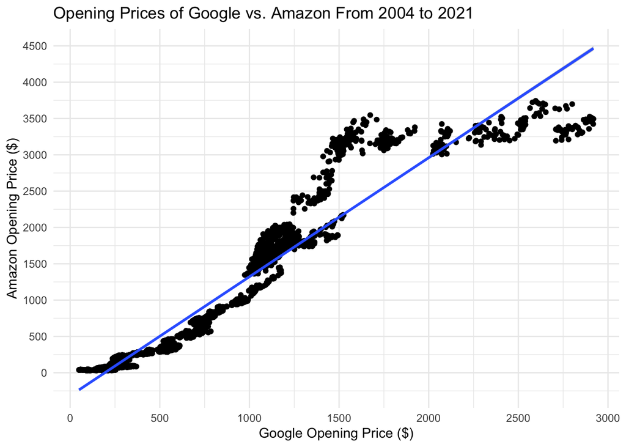

```r
joinData %>% ggplot(aes(x=Open.goog,y=Open.amzn)) + geom_point() + geom_smooth(method='lm') + ggtitle("Opening Prices of Google vs. Amazon From 2004 to 2021",) + xlab("Google Opening Price ($)") + ylab("Amazon Opening Price ($)") + scale_y_continuous(breaks = seq(0,5000,500)) + scale_x_continuous(breaks = seq(0,5000,500)) + theme_minimal()
```

We can see that there is a linear relationship between the opening prices of Amazon and Google from 2004 to 2021, which is demonstrated by the blue regression line. Something important to note, that I believe is easy to overlook, is the scales of the axes. The x-axis only ranges between 0 and 3000 dollars whereas the y-axis ranges between 0 and 4500 dollars. So, the regression line indicates points at which the opening price for Amazon is larger than the opening price for Google. Something that I found particularly interesting is that the graph appears parabolic in the domain of 0 to 1500 dollars, but shortly afterwards it seems to “correct” to a linear correlation. There are several possible explanations of this behavior. My theory is that, at some point, Amazon had explosive growth relative to Google, but then Google also experienced explosive growth shortly afterwards. Overall, the results of this graph are in-line with the principle that stocks of the same industry tend to follow similar price movements.

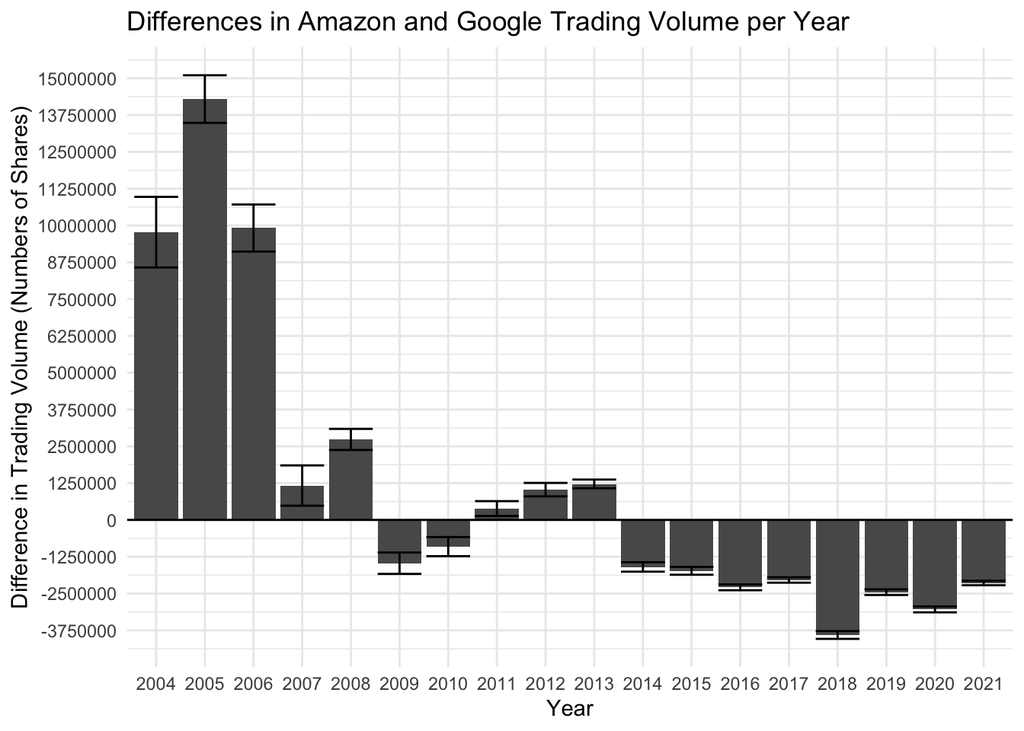

```r
joinData %>% ggplot(aes(x=year,y=diffVolume)) + geom_bar(stat="summary",fun=mean) + geom_errorbar(stat="summary", fun.data=mean_se) + scale_y_continuous(breaks = seq(-2e7,2e7,1.25e6)) + geom_hline(yintercept=0) + theme_minimal() + ggtitle("Differences in Amazon and Google Trading Volume per Year") + ylab("Difference in Trading Volume (Numbers of Shares)") + xlab("Year")
```

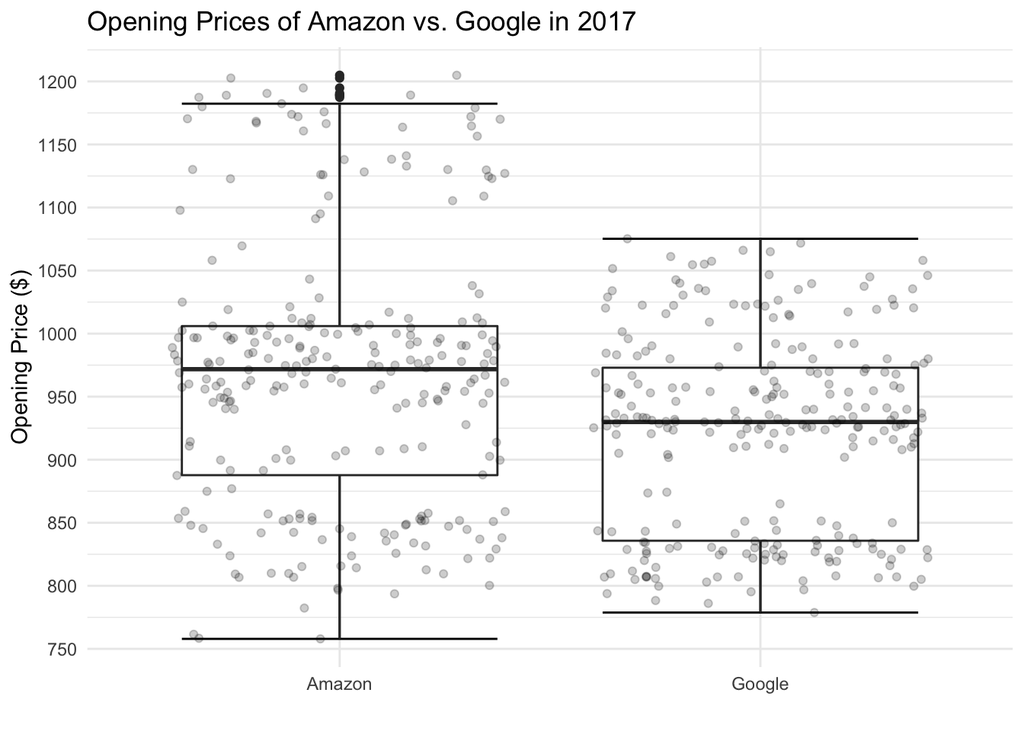

```r
# note: had to wrangle a little to create grouped box plot
open = joinData %>% filter(year=="2017") %>% pivot_longer(c(Open.goog,Open.amzn),names_to = "ticker",values_to="open") %>% select(ticker,open)
open$ticker = str_replace(open$ticker,"Open.","")
open %>% ggplot(aes(x=ticker,y=open)) + stat_boxplot(geom='errorbar') + geom_boxplot() + geom_jitter(alpha=0.2) + ggtitle("Opening Prices of Amazon vs. Google in 2017") + ylab("Opening Price ($)") + xlab("") + scale_y_continuous(breaks=seq(700,1300,50)) + scale_x_discrete(labels=c("Amazon","Google")) + theme_minimal()
```

I chose 2017 simply because that was the year that both Amazon and Google began rapid increases in value. However, it is simple to change the filter to any year. We can see that Amazon had both a wider spread and higher quartiles than Google in 2017. Amazon also had outliers on its upper end, whereas Google did not. I believe that this indicates that Amazon was much more volatile than Google in 2017. This is consistent with my wrangling discussion, in which I posited that Amazon had higher volatility than Google because it had more days with higher trading volume. We can also see in the second graph that Amazon had higher trading volume than Google in 2017. I am curious if this trend, relative spreads in the third graph reflecting the signs in the second graph, holds for all years.

### Closing Remarks

My prediction that the price movements of Google and Amazon would be similar was correct. In the future, I would like to explore the relationship between the relative spreads of opening prices and relative trading volumes, as mentioned in the discussion of the third graph. It would also be interesting to examine what factors influence price movements, such as those displayed in the first graph. Lastly, I found that the company with the smaller mean trading volume, Amazon, also had greater mean prices. I wonder if this is also true of other companies.